# Not Always A Matter Of Context: direct effects of red on arousal but context-dependent moderations on valence

Nicole LaGrange, Tania Delgado, Pamela Riviere

2017-12-14

**Paper.** Buechner and Maier (2016) Not always a matter of context: direct effects of red on arousal but context-dependent moderations on valence. *PeerJ*

**Summary.** This study aimed to determine whether colors intrinsically elicit different degrees of physiological arousal, or whether their perceptual effects are dictated by the contextual circumstances in which the colors are experienced. To investigate this question, Buechner and Maier (2016) sorted subjects into one of *four experimental categories*. These categories consisted of assessing the arousal and valence properties of either:

- four “test-relevant” pictures framed in red
- four “test-relevant” pictures framed in blue
- four “neutral” pictures framed in red
- four “neutral” pictures framed in blue

To assess arousal, participants in each category were asked: “Describe how physiologically arousing do you think [the situation in this picture] is”. To assess valence, participants in each category were asked: “Describe how unpleasant do you think [the situation in this picture] is”. In response to each question, participants assigned each picture a number from 1 (not at all) to 9 (extremely). The authors then take the **mean** of the **arousal** and **valence ratings across the four pictures** rated by a given participant.

**Hypothesis.** The color **red** should increase arousal perceptions for both neutral and test-relevant picture contexts, but it should increase valence perceptions only for test-relevant pictures.

The dataframe contains rows of subjects with their corresponding assessement of a given picture as physically arousing or unpleasant (a measure of valence).

```r
library(foreign)
library(dplyr)
library(tidyverse)
library(DescTools)

color_data_pr = read.csv("color_data_pr.csv")
```

### Replicating Analyses and Figures

A note on the response variables used in this experiment: the four pictures presented to each participant contained figures that were matched for unpleasantness (valence) and arousal quality by “experts”. However, it is not clear that this expert assessment guarantees uniform responses across the four different pictures (for instance, picture1 may have elicited an arousal rating of 2, whereas picture2 elicited an arousal rating of 7 – taking the mean of these would not necessarily constitute a meaningful arousal assesment). So it might be wise to take the following results with this caveat in mind, even though we trust that authors invested time in norming their stimuli.

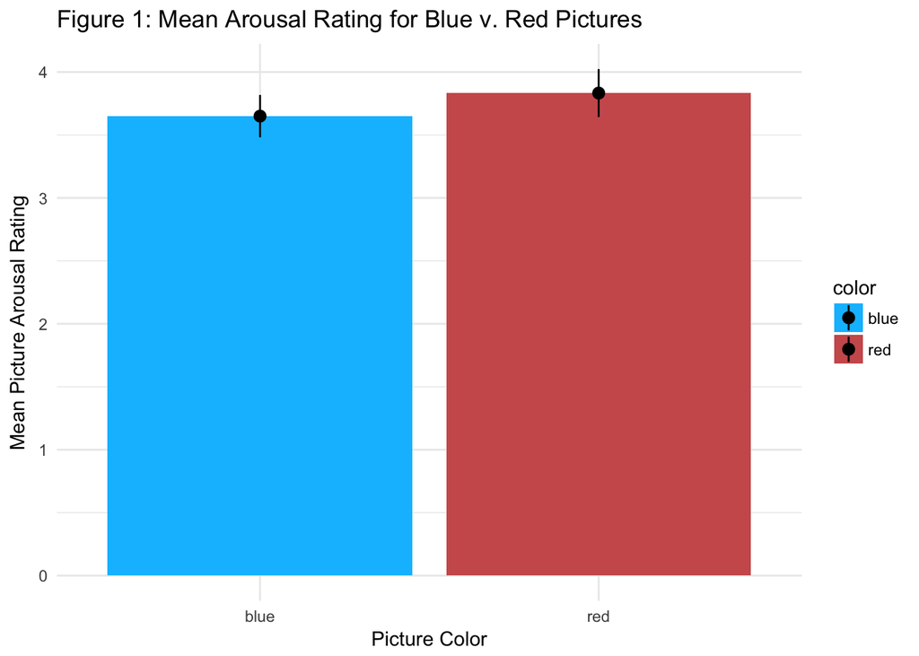

```r
# Figure 1 replicated
fig1 <- ggplot(color_data_pr, aes(x=color, Pic_arousal_MEAN, fill = color)) +
  geom_bar(stat="summary", fun.y="mean", position="dodge") +
  stat_summary(fun.y = function(x){mean(x)},
               fun.ymin = function(x){mean(x) - 2*sd(x)/sqrt(length(x))},
               fun.ymax = function(x){mean(x) + 2*sd(x)/sqrt(length(x))},
               geom= 'pointrange') +
  scale_fill_manual(values = alpha(c("deepskyblue", "indianred"), 1))+
  labs(title = 'Figure 1: Mean Arousal Rating for Blue v. Red Pictures', y = 'Mean Picture Arousal Rating', x = 'Picture Color') + theme_minimal()
fig1
```

```r
# ANOVA with color and context as between-subjects factors for arousal ratings.
# no significant interaction between color and context on arousal ratings.

# to get the reported effect of color
(interact.aro.color = summary(aov(data= color_data_pr, Pic_arousal_MEAN ~ pic * color)))
```

```
##              Df Sum Sq Mean Sq F value Pr(>F)
## pic           1 100.97  100.97 113.604 <2e-16 ***
## color         1   3.85    3.85   4.335 0.0382 *
## pic:color     1   0.98    0.98   1.101 0.2948
## Residuals   301 267.53    0.89
## ---
## Signif. codes:  0 '***' 0.001 '**' 0.01 '*' 0.05 '.' 0.1 ' ' 1
```

```r
# to get the reported effect of context (note: the variable "pic" indicates context, whether test-relevant or neutral picture)
(interact.aro.pic = summary(aov(data= color_data_pr, Pic_arousal_MEAN ~ color * pic)))
```

```
##              Df Sum Sq Mean Sq F value Pr(>F)
## color         1   2.55    2.55   2.873 0.0911 .
## pic           1 102.27  102.27 115.066 <2e-16 ***
## color:pic     1   0.98    0.98   1.101 0.2948
## Residuals   301 267.53    0.89
## ---
## Signif. codes:  0 '***' 0.001 '**' 0.01 '*' 0.05 '.' 0.1 ' ' 1
```

A **very** subtle effect of **color** on mean arousal ratings **(F(1,301) = 4.34, p = 0.038)**. In the original paper, authors rescale their y-axis to visually enhance the difference in means. Additionally, we only obtain matching values for the reported F-statistics if we run two different ANOVAs, with different ordering of the predictors. However, the paper reports the results as though they were generated from the same analysis. Interestingly, the main effect of color happens to wash out when it is used to explain most of the variance in the model **(F(1,301) = 2.87, p = 0.0911)**.

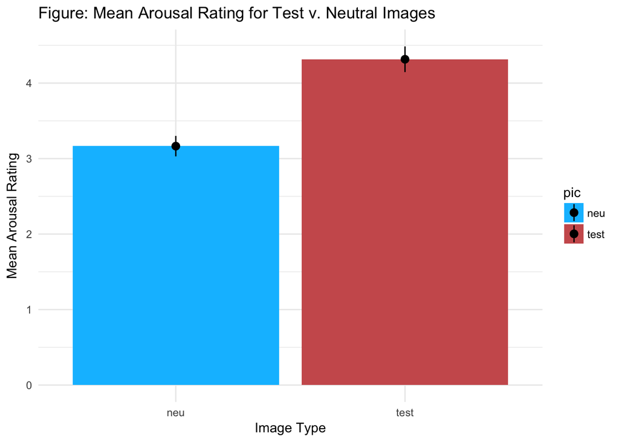

```r
# New plot showing difference between test and neutral contexts

# Similar to Fig 1, but with test vs neu
fig.pic <- ggplot(color_data_pr, aes(x=pic, Pic_arousal_MEAN, fill = pic)) +
  geom_bar(stat="summary", fun.y="mean", position="dodge") +
  stat_summary(fun.y = function(x){mean(x)},
               fun.ymin = function(x){mean(x) - 2*sd(x)/sqrt(length(x))},
               fun.ymax = function(x){mean(x) + 2*sd(x)/sqrt(length(x))},
               geom= 'pointrange') +
  scale_fill_manual(values = alpha(c("deepskyblue", "indianred"), 1)) +
  labs(title = 'Figure: Mean Arousal Rating for Test v. Neutral Images',
       y = 'Mean Arousal Rating',
       x = 'Image Type')+
  theme_minimal()
fig.pic
```

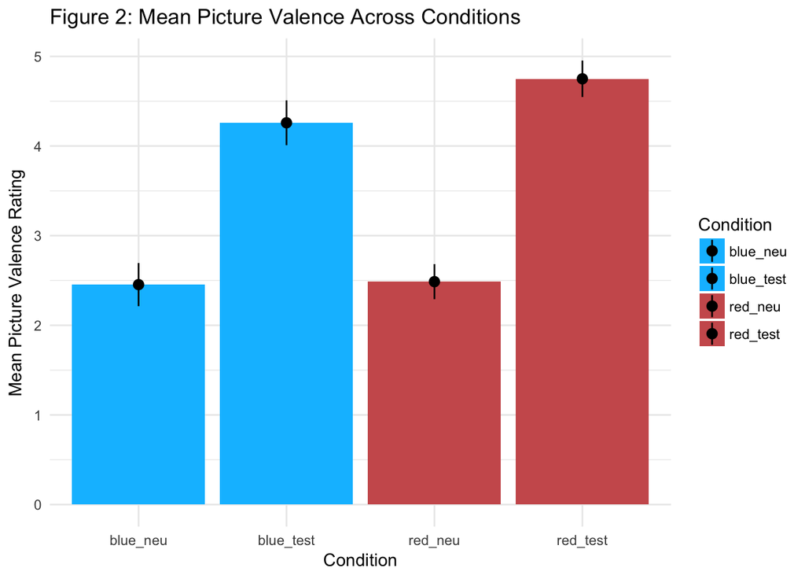

```r
# Figure 2 replicated

fig2 <- ggplot(color_data_pr, aes(x=Condition, Pic_valence_MEAN, fill = Condition)) +
  geom_bar(stat='summary', fun.y='mean') +
  stat_summary(fun.y = function(x){mean(x)},
               fun.ymin = function(x){mean(x) - 2*sd(x)/sqrt(length(x))},
               fun.ymax = function(x){mean(x) + 2*sd(x)/sqrt(length(x))},
               geom= 'pointrange') +
  scale_fill_manual(values = alpha(c("deepskyblue", "deepskyblue", "indianred", "indianred"), 1)) +
  labs(title = 'Figure 2: Mean Picture Valence Across Conditions', y = "Mean Picture Valence Rating", x = "Condition") +
  theme_minimal()
fig2
```

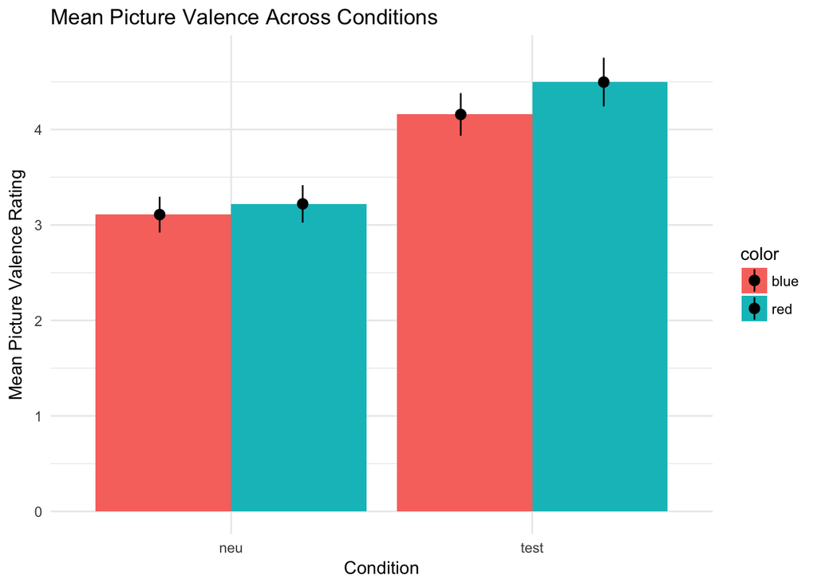

```r
# Recreated version:
ggplot(color_data_pr, aes(x=pic, Pic_arousal_MEAN, fill=color)) +
  geom_bar(stat="summary", fun.y="mean", position="dodge") +
  stat_summary(fun.y = function(x){mean(x)},
               fun.ymin = function(x){mean(x) - 2*sd(x)/sqrt(length(x))},
               fun.ymax = function(x){mean(x) + 2*sd(x)/sqrt(length(x))},
               geom= 'pointrange', position = position_dodge(0.95)) +
  labs(x = "Condition", y = "Mean Picture Valence Rating", title = 'Mean Picture Valence Across Conditions') +
  theme_minimal()
```

```r
# ANOVA with color and ocntest as between-subjects factors conducted on valence.
# for color
interact.val.color = aov(data= color_data_pr, Pic_valence_MEAN ~ pic * color)
summary(interact.val.color)
```

```
##              Df Sum Sq Mean Sq F value Pr(>F)
## pic           1 310.48  310.48 321.005 <2e-16 ***
## color         1   5.17    5.17   5.345 0.0215 *
## pic:color     1   3.98    3.98   4.119 0.0433 *
## Residuals   301 291.13    0.97
## ---
## Signif. codes:  0 '***' 0.001 '**' 0.01 '*' 0.05 '.' 0.1 ' ' 1
```

```r
# for context
(interact.val.pic = summary(aov(data= color_data_pr, Pic_valence_MEAN ~ color * pic)))
```

```
##              Df Sum Sq Mean Sq F value Pr(>F)
## color         1   2.67    2.67   2.763 0.0975 .
## pic           1 312.98  312.98 323.587 <2e-16 ***
## color:pic     1   3.98    3.98   4.119 0.0433 *
## Residuals   301 291.13    0.97
## ---
## Signif. codes:  0 '***' 0.001 '**' 0.01 '*' 0.05 '.' 0.1 ' ' 1
```

Note, the F-statistic for main effect of **context** (F(1,301) = 323.59, p < 0.001). slightly differs from the reported one (F(1,301) = 325.48, p < 0.001).

Note, the F-statistic for main effect of **color** (F(1,301) = 5.345, p = 0.02) slightly differs from the reported one (F(1,301) = 5.40, p = 0.02).

**Sheffe Post Hoc Test for multiple comparisons.**

```r
# scheffe Post Hoc Test Replication
(schef <- PostHocTest(x=interact.val.color, method="scheffe"))
```

```
##
##   Posthoc multiple comparisons of means : Scheffe Test
##     95% family-wise confidence level
##
## $pic
##              diff   lwr.ci   upr.ci   pval
## test-neu 2.017899 1.701262 2.334536 <2e-16 ***
##
## $color
##               diff      lwr.ci    upr.ci   pval
## red-blue 0.2603203 -0.05645299 0.5770936 0.1511
##
## $`pic:color`
##                           diff      lwr.ci     upr.ci   pval
## test:blue-neu:blue  1.80531189  1.36376193  2.2468619 <2e-16 ***
## neu:red-neu:blue    0.03306562 -0.41400166  0.4801329 0.9976
## test:red-neu:blue   2.29605263  1.83969846  2.7524068 <2e-16 ***
## neu:red-test:blue  -1.77224627 -2.21231449 -1.3321781 <2e-16 ***
## test:red-test:blue  0.49074074  0.04124101  0.9402405 0.0257 *
## test:red-neu:red    2.26298701  1.80806636  2.7179077 <2e-16 ***
##
## ---
## Signif. codes:  0 '***' 0.001 '**' 0.01 '*' 0.05 '.' 0.1 ' ' 1
```

The authors chose to report the results for the comparison between the test:red interaction and the test:blue interaction **(diff 0.491, p = 0.0257)**, in order to support the claim that the color red enhances valence perceptions. This, by itself, does not seem to support that particular claim. It does suggest that there is a slight bias for individuals to perceive an affectively charged context as unpleasant if red is present, rather than blue. Another test may be to evaluate whether the test:blue - neu:blue comparison **(diff 1.805, p < 0.001)** is significantly different from test:red - neu:red **(diff 2.263, p < 0.001)**.

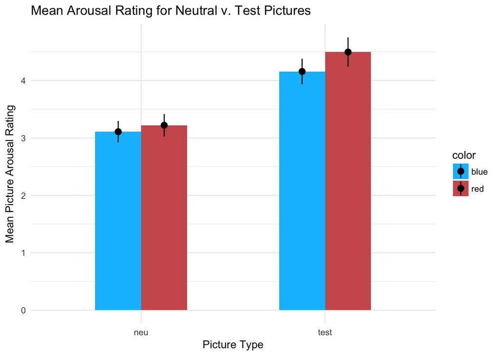

```r
arous.neu.vs.test <- ggplot(color_data_pr, aes(x=pic, Pic_arousal_MEAN, fill=color)) +
  geom_bar(stat="summary", fun.y="mean", position="dodge", width = 0.5) +
  scale_fill_manual(values = alpha(c("deepskyblue", "indianred"), 1))+
  stat_summary(fun.y = function(x){mean(x)},
               fun.ymin = function(x){mean(x) - 2*sd(x)/sqrt(length(x))},
               fun.ymax = function(x){mean(x) + 2*sd(x)/sqrt(length(x))},
               geom= 'pointrange', position = position_dodge(0.5)) +
  labs(title = 'Mean Arousal Rating for Neutral v. Test Pictures', y = 'Mean Picture Arousal Rating', x = 'Picture Type') +
  theme_minimal()
arous.neu.vs.test
```

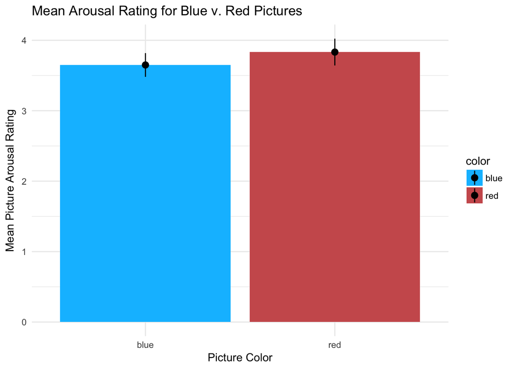

```r
arous.by.color <- ggplot(data= color_data_pr, aes(x=color, y= Pic_arousal_MEAN, fill=color)) +
  geom_bar(stat="summary", fun.y="mean", position="dodge") +
  scale_fill_manual(values = alpha(c("deepskyblue", "indianred"), 1)) +
  stat_summary(fun.y = function(x){mean(x)},
               fun.ymin = function(x){mean(x) - 2*sd(x)/sqrt(length(x))},
               fun.ymax = function(x){mean(x) + 2*sd(x)/sqrt(length(x))},
               geom= 'pointrange') +
  labs(title = 'Mean Arousal Rating for Blue v. Red Pictures', y = 'Mean Picture Arousal Rating', x = 'Picture Color') + theme_minimal()
arous.by.color
```

```r
summary(aov(data = color_data_pr, Pic_arousal_MEAN ~ color))
```

```
##              Df Sum Sq Mean Sq F value Pr(>F)
## color         1    2.6   2.554   2.087   0.15
## Residuals   303  370.8   1.224
```

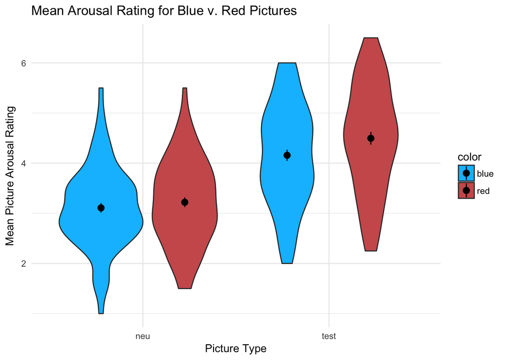

```r
### Beyond the paper
########## TODO: Run ANCOVA, using trait and test anxiety as the controls, figures we chose to improve, why are they improvements (violin plots here and why they are a nicer representation of the distribution)

### Violin Plot for Arousal Mean
arousal.violin <- ggplot(color_data_pr, aes(x=pic, Pic_arousal_MEAN, fill=color)) +geom_violin() +
  stat_summary(fun.data = mean_se, geom = 'pointrange', color='black', position = position_dodge(.9)) +
   scale_fill_manual(values = alpha(c("deepskyblue", "indianred"), 1))+
  labs(title = 'Mean Arousal Rating for Blue v. Red Pictures', y = 'Mean Picture Arousal Rating', x = 'Picture Type') + theme_minimal()
arousal.violin
```

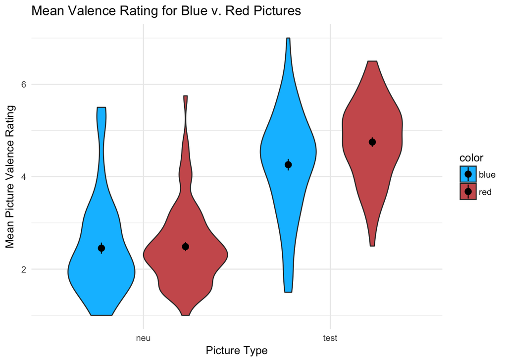

```r
### Violin Plot for Valence Mean
valence.violin <- ggplot(color_data_pr, aes(x=pic, Pic_valence_MEAN, fill=color)) + geom_violin() +   stat_summary(fun.data = mean_se, geom = 'pointrange', color='black', position = position_dodge(.9))+
   scale_fill_manual(values = alpha(c("deepskyblue", "indianred"), 1))+labs(title = 'Mean Valence Rating for Blue v. Red Pictures', y = 'Mean Picture Valence Rating', x = 'Picture Type') + theme_minimal()
valence.violin
```

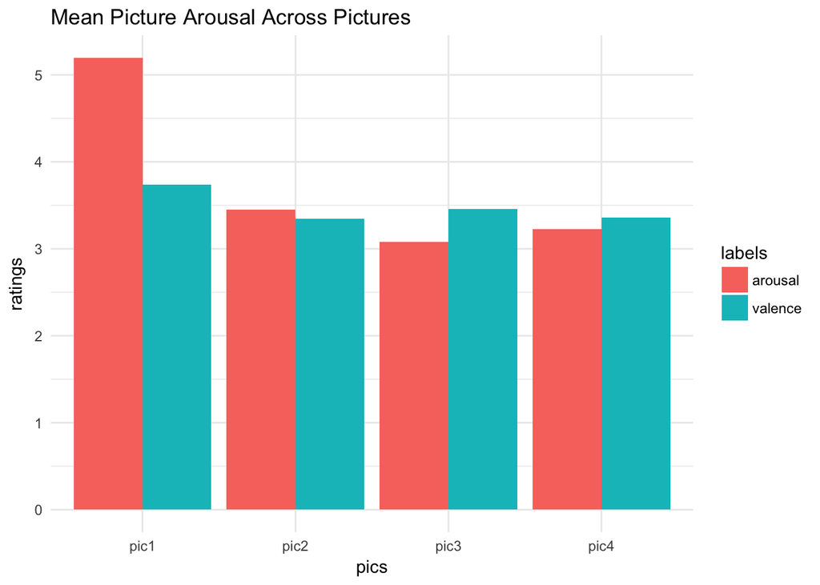

```r
# bar plots for the distribution of arousal and valence judgements for each picture
arousal_by_pic = c(mean(color_data_pr$pic1_arousal),
                   mean(color_data_pr$pic2_arousal),
                   mean(color_data_pr$pic3_arousal),
                   mean(color_data_pr$pic4_arousal))

valence_by_pic = c(mean(color_data_pr$pic1_valence), mean(color_data_pr$pic2_valence), mean(color_data_pr$pic3_valence), mean(color_data_pr$pic4_valence))

pics = c('pic1', 'pic2', 'pic3', 'pic4','pic1', 'pic2', 'pic3', 'pic4')
new.df = data.frame(arousal_by_pic, valence_by_pic, pics)

labels = c('arousal', 'arousal', 'arousal', 'arousal',
           'valence', 'valence', 'valence', 'valence')


ratings = c(arousal_by_pic, valence_by_pic)
new.df2 = data.frame(ratings, pics, labels)

arousal.across.pics <- ggplot(new.df2, aes(x=pics, ratings, fill=labels)) +
  geom_bar(stat="identity", position="dodge") +
 labs(title = 'Mean Picture Arousal Across Pictures') +
  theme_minimal()
arousal.across.pics
```

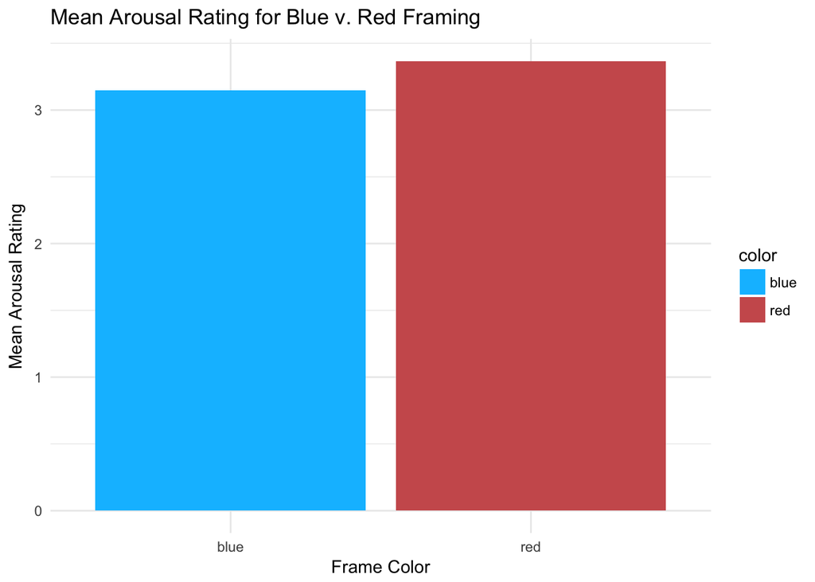

```r
# Without Pic 1
new.aro.df <- data.frame(color=color_data_pr$color,
                      pic=color_data_pr$pic,
                      pic2_aro=color_data_pr$pic2_arousal,
                      pic3_aro=color_data_pr$pic3_arousal,
                      pic4_aro=color_data_pr$pic4_arousal)

new.aro.df$aro.mean <- apply(new.aro.df[,3:5], 1, mean)
interact.new.aro.pic = anova(lm(data = new.aro.df, aro.mean ~ color*pic))
interact.new.aro.col = anova(lm(data = new.aro.df, aro.mean ~ pic*color))

fig.1.nopic1 <- ggplot(new.aro.df, aes(x=color, aro.mean, fill=color))+
  geom_bar(stat="summary", fun.y="mean", position="dodge")+
  scale_fill_manual(values = alpha(c("deepskyblue", "indianred"), 1))+
  labs(title = 'Mean Arousal Rating for Blue v. Red Framing',
       y = 'Mean Arousal Rating',
       x = 'Frame Color')+
  theme_minimal()
fig.1.nopic1
```

**some ANOVAs.**

```r
# Let's look at main and interaction effects
interact.val = anova(lm(data = color_data_pr, Pic_valence_MEAN ~ color*pic))
interact.aro = anova(lm(data = color_data_pr, Pic_arousal_MEAN ~ color*pic))


#is this a valid way to go about this? - tania
anova.val.cond = anova(lm(data = color_data_pr, Pic_valence_MEAN ~ Condition))
anova.aro.cond = anova(lm(data = color_data_pr, Pic_arousal_MEAN ~ Condition))

interact.val.cond = anova(lm(data = color_data_pr, Pic_valence_MEAN ~ Condition*Pic_arousal_MEAN))
interact.aro.cond = anova(lm(data = color_data_pr, Pic_arousal_MEAN ~ Condition*Pic_valence_MEAN))
```

**some ANCOVAs.**

```r
#is this the right way to go about this? - tania

# ANCOVA with valence rating as the response variable, trait or test anxiety as controls
ancova.val.trait_anxiety = anova(lm(data = color_data_pr, Pic_valence_MEAN ~ STAI_MEAN + Condition))
ancova.val.test_anxiety = anova(lm(data = color_data_pr, Pic_valence_MEAN ~ AEQanxiety_MEAN + Condition))

# ANCOVA with arousal rating as the response variable, trait or test anxiety as controls
ancova.aro.trait_anxiety = anova(lm(data = color_data_pr, Pic_arousal_MEAN ~ STAI_MEAN + Condition))
ancova.aro.test_anxiety = anova(lm(data = color_data_pr, Pic_arousal_MEAN ~ AEQanxiety_MEAN + Condition))
```

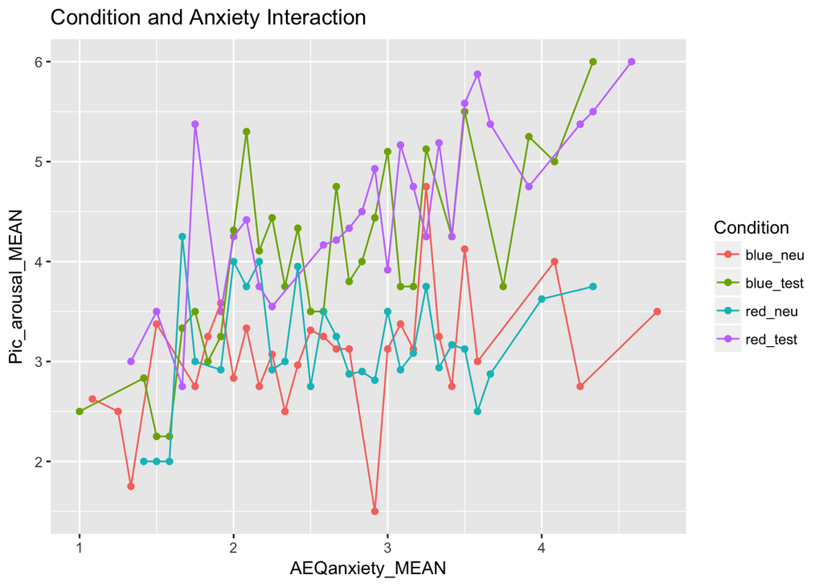

```r
# There is an interaction between Condition and Anxiety

anxiety.interaction <- color_data_pr %>%
  ggplot() +
  aes(x = AEQanxiety_MEAN, color = Condition, group = Condition, y = Pic_arousal_MEAN) +
  stat_summary(fun.y = mean, geom = "point") +
  stat_summary(fun.y = mean, geom = "line")+ ggtitle('Condition and Anxiety Interaction')

anxiety.interaction
```